# Setup and Install Software

Morphometrics Lesson 1

Author

Ryan N. Felice

## Install Packages

First we need to install the software packages that we will use. To install a single R package, we use the `install.packages` function and put the package name in quotes

```r
install.packages("geomorph")
```

But to speed things up we can use the three lines of code below. Here we make a list of all the packages we want to have, check if they are installed or not, and then install all of the packages which are missing from our computer.

```r
my_packages <- c("StereoMorph",
                 "Momocs",
                 "geomorph",
                 "Morpho",
                 "stringr",
                 "sfsmisc",
                 "pixmap",
                 "tiff",
                 "splancs",
                 "jpeg",
                 "mvMORPH",
                 "remotes",
                 "Rvcg")
not_installed <- my_packages[!(my_packages %in%
                                 installed.packages()[ , "Package"])]
if(length(not_installed)) install.packages(not_installed)

#note that as of may 2026, momocs is not on cran so we might have to do this:

pak::pkg_install("MomX/Momocs")
```

## Load Packages

Now that the software is loaded, we can load the packages into R so that they are read to use. You’ll have to do this again each time you open R

```r
library("StereoMorph")
library("Momocs")
library("geomorph")
library("Morpho")
library("rgl")
```

## Loading built-in datasets

some of our R pacakges have example data built in. We can load in that data to our R environment with the `data` function

```r
#from the Momocs package, outlines of whisky and beer bottles
data(bot)
bot
```

```
Out (outlines)
  - 40 outlines, 162 +/- 21 coords (in $coo)
  - 2 classifiers (in $fac):
# A tibble: 40 × 2
  type   fake
  <fct>  <fct>
1 whisky a
2 whisky a
3 whisky a
4 whisky a
5 whisky a
6 whisky a
# ℹ 34 more rows
  - also: $ldk
```

```r
names(bot)
```

```
 [1] "brahma"         "caney"          "chimay"         "corona"
 [5] "deusventrue"    "duvel"          "franziskaner"   "grimbergen"
 [9] "guiness"        "hoegardeen"     "jupiler"        "kingfisher"
[13] "latrappe"       "lindemanskriek" "nicechouffe"    "pecheresse"
[17] "sierranevada"   "tanglefoot"     "tauro"          "westmalle"
[21] "amrut"          "ballantines"    "bushmills"      "chivas"
[25] "dalmore"        "famousgrouse"   "glendronach"    "glenmorangie"
[29] "highlandpark"   "jackdaniels"    "jb"             "johnniewalker"
[33] "magallan"       "makersmark"     "oban"           "oldpotrero"
[37] "redbreast"      "tamdhu"         "wildturkey"     "yoichi"
```

Take a look at the outline of the bottle of Franziskaner, a Bavarian beer

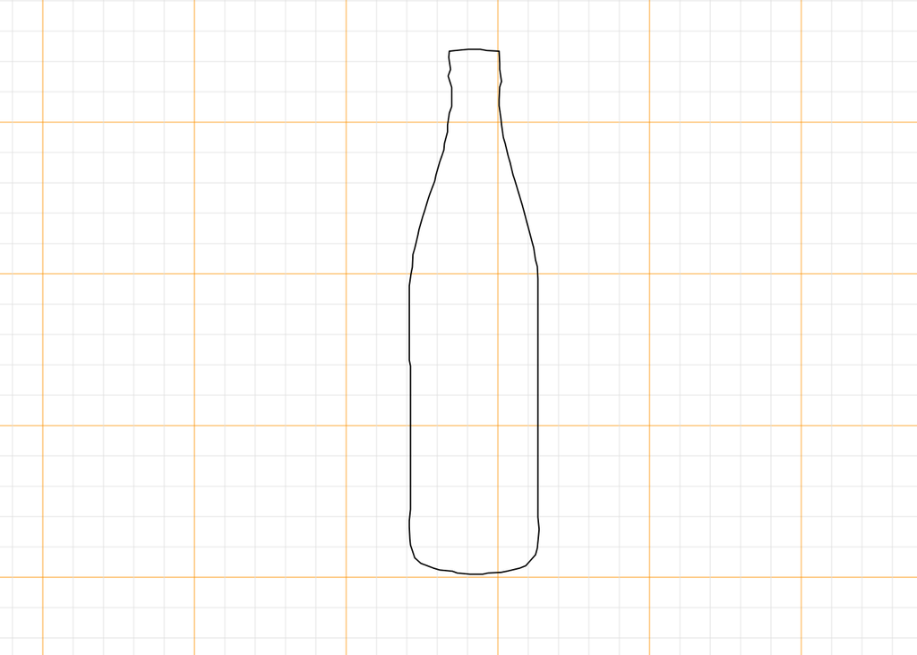

```r
bot[7]  |> paper_grid()  |> draw_outline()
```

Now lets try visualizing some 2D landmark data. This example data describes head shape of the lungless salamander *Plethodon* using 12 landmarks.

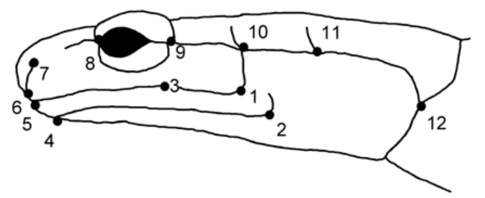

*Plethodon* salamander head with landmarks

First, load the data

```r
#from the geomorph package
data(plethodon)
```

Try displaying the landmark data for first specimen

```r
plethodon$land[,,1]
```

```
          [,1]     [,2]
 [1,]  8.89372 53.77644
 [2,]  9.26840 52.77072
 [3,]  5.56104 54.21028
 [4,]  1.87340 52.75100
 [5,]  1.28180 53.18484
 [6,]  1.24236 53.32288
 [7,]  0.84796 54.70328
 [8,]  3.35240 55.76816
 [9,]  6.29068 55.70900
[10,]  8.87400 55.25544
[11,] 10.74740 55.43292
[12,] 14.39560 52.75100
```

And try plotting a subset of the data

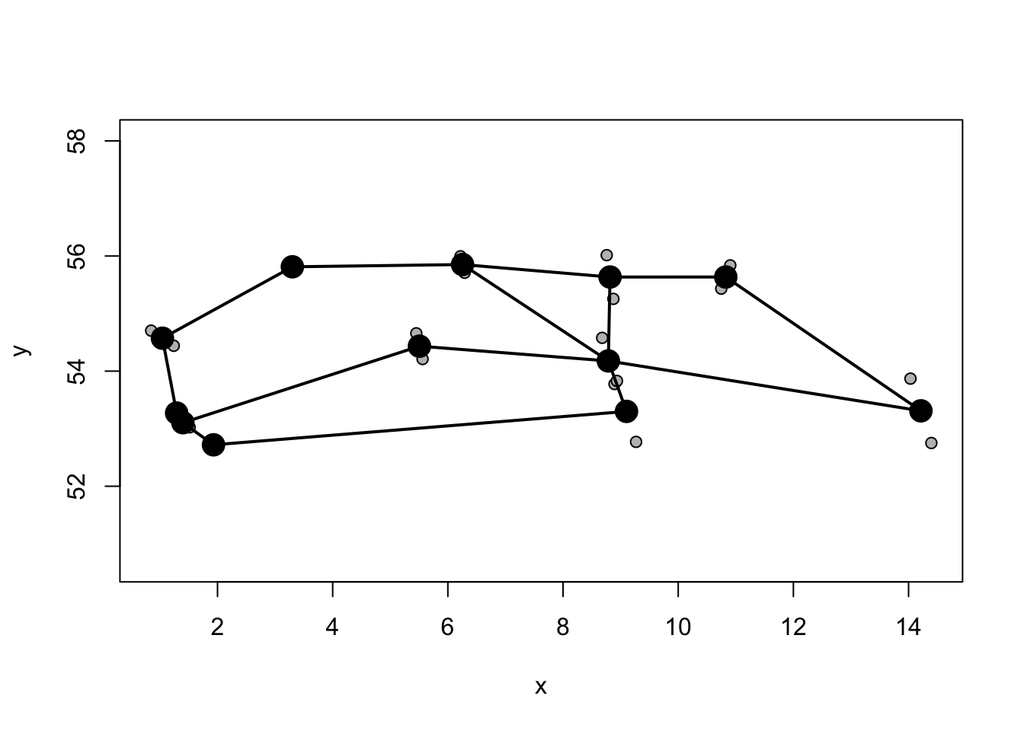

```r
plotAllSpecimens(plethodon$land[,,1:2],links = plethodon$links)
```

Finally, plot some 3D data. This will open a new window.

> **Note**: that if you are on MacOS 26 Tahoe, some 3D graphics stuff is bugged right now unless you upgrade to version 26.5 or higher and rebuild the `rgl` package. If you are on an earlier version of Tahoe, you might have to run this `options(rgl.useNULL = TRUE, rgl.printRglwidget = TRUE)` first to get 3D visuals in R to work at all.

```r
data(scallopPLY)
spheres3d(scallopPLY$coords,col="red")
```

[interactive chart not shown]

## Some other installations

Some of our analyses might require additional software packages that cannot be installed directly through R. Most folks will have these things installed already, but I will leave these links here just in case

XQuartz for Mac: https://www.xquartz.org

ImageMagik: https://imagemagick.org/script/download.php

## Exercise:

Try playing with the plotting functions in Momocs to render another outline shape (from data object `bot` or `shapes` within `Momocs`). Experiment with different colors, line types and thicknesses.